# Donovan Mitchell’s scoring using R

### Robert Bischoff

March 4th, 2019

The Utah Jazz and Donovan Mitchell had an exciting week. Jazz fans know Donovan Mitchell started off the season slow but has been on fire lately. I wanted to take a look at some of his recent scoring, but I wanted to do it in R because it’s fun to write my own code and I can run this analysis over again whenever I want. Maybe you like stats and want to do it yourself and maybe you don’t. The code is hidden by default, but click the code button and you can follow along*.

> View this post on Instagram

> [🕷🕸🤐](https://www.instagram.com/p/BuiQgEVgV21/?utm_source=ig_embed&utm_medium=loading)

> A post shared by [Donovan Mitchell](https://www.instagram.com/spidadmitchell/?utm_source=ig_embed&utm_medium=loading) (@spidadmitchell) on Mar 2, 2019 at 9:58pm PST

First step for the analysis is to get the packages and download the data. I’ll use R to download the up to date stats from NBA.com.

Here’s what the first few rows look like:

```r
# first step - load packages
# install.packages('devtools') # uncomment to install if needed
# install.packages('pacman') # uncomment to install if needed
# devtools::install_github('stephematician/statsnbaR') # uncomment to install if needed
library(pacman) # this package loads or downloads packages as needed.
# load all packages used
p_load(statsnbaR,tidyverse,formattable,ggthemes)
# download player data
players <- player_game_logs('nba',2018) # takes a long time depending on connection
formattable(head(players))
```

| season | person_id | player_name | team_abbr | team_name | game_id | game_date | home | win | mins | fgm | fga | fg3m | fg3a | ftm | fta | oreb | dreb | reb | ast | stl | blk | tov | pf | pts | plus_minus | video |
| --- | --- | --- | --- | --- | --- | --- | --- | --- | --- | --- | --- | --- | --- | --- | --- | --- | --- | --- | --- | --- | --- | --- | --- | --- | --- | --- |
| 22018 | 201935 | James Harden | HOU | Houston Rockets | 21800710 | 2019-01-23 | FALSE | TRUE | 40 | 17 | 38 | 5 | 20 | 22 | 25 | 6 | 9 | 15 | 4 | 5 | 0 | 5 | 3 | 61 | 19 | TRUE |
| 22018 | 202689 | Kemba Walker | CHA | Charlotte Hornets | 21800225 | 2018-11-17 | TRUE | FALSE | 45 | 21 | 34 | 6 | 14 | 12 | 12 | 0 | 7 | 7 | 4 | 4 | 0 | 9 | 2 | 60 | 1 | TRUE |
| 22018 | 201935 | James Harden | HOU | Houston Rockets | 21800925 | 2019-02-28 | TRUE | TRUE | 44 | 16 | 32 | 8 | 18 | 18 | 18 | 2 | 5 | 7 | 10 | 4 | 1 | 4 | 1 | 58 | 10 | TRUE |
| 22018 | 201935 | James Harden | HOU | Houston Rockets | 21800659 | 2019-01-16 | TRUE | FALSE | 45 | 16 | 34 | 5 | 19 | 21 | 23 | 1 | 9 | 10 | 6 | 1 | 1 | 4 | 5 | 58 | -8 | TRUE |
| 22018 | 201935 | James Harden | HOU | Houston Rockets | 21800646 | 2019-01-14 | TRUE | TRUE | 34 | 17 | 33 | 6 | 15 | 17 | 18 | 2 | 7 | 9 | 2 | 2 | 1 | 5 | 4 | 57 | 25 | TRUE |
| 22018 | 200746 | LaMarcus Aldridge | SAS | San Antonio Spurs | 21800619 | 2019-01-10 | TRUE | TRUE | 49 | 20 | 33 | 0 | 0 | 16 | 16 | 4 | 5 | 9 | 4 | 0 | 4 | 5 | 2 | 56 | 7 | TRUE |

## Improvement since the start of the season

Next, let’s get Mitchell’s data, look at his scoring over the season, and plot his per-game scoring.

```r
# filter for Donovan Mitchell
DM45 <- players %>% filter(player_name == "Donovan Mitchell")
# arrange the games from most recent to
DM45 <- DM45 %>% arrange(desc(game_date))
# create a data frame containing splits of Mitchell's scoring over the season
splits <- tibble(Player = "Donovan Mitchell",
                 L10 = round(mean(DM45$pts[1:10]),1),
                 L20 = round(mean(DM45$pts[1:20]),1),
                 L30 = round(mean(DM45$pts[1:30]),1),
                 L40 = round(mean(DM45$pts[1:40]),1),
                 L50 = round(mean(DM45$pts[1:50]),1),
                 `All games` = round(mean(DM45$pts),1))
# display table
formattable(splits, align = c('l','c','c','c','c','c','c'))
```

| Player | L10 | L20 | L30 | L40 | L50 | All games |
| --- | --- | --- | --- | --- | --- | --- |
| Donovan Mitchell | 27.5 | 28.4 | 25.7 | 24.4 | 23.5 | 23.3 |

It’s pretty obvious how his overall scoring has gone up throughout the year. Next year’s task is to figure out how to not start as slow as his first two years.

Now let’s look at the plot:

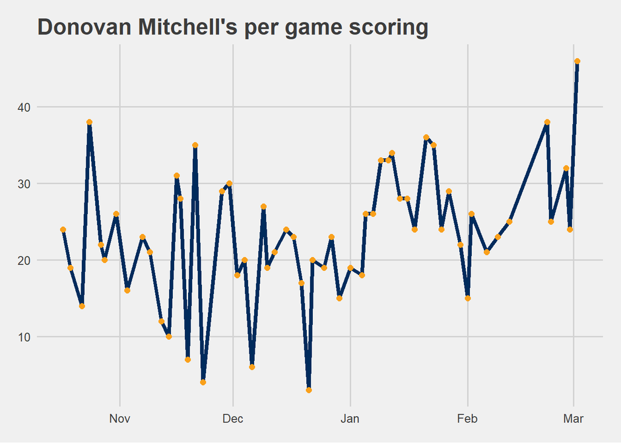

```r
# plot each game's scoring over the course of the season
ggplot(DM45, aes(game_date,pts)) + geom_path(size = 1.5, color = "#002B5C") +
  geom_point(size = 2, color = "#F9A01B") +
  ggtitle("Donovan Mitchell's per game scoring") + theme_fivethirtyeight()
```

He had a rough stretch through a tough schedule from mid-November to mid-December. Since then his scoring has been higher and more consistent with only one game below 20 points since just after the start of the year.

## Scoring comparison

Let’s cherry pick January 5th, as his scoring really picks up then. We’ll compare the top scorers after that date and take a look at scoring and efficiency. My biggest beef with Mitchell, as much as I love watching him play, is he’s not the most efficient scorer at times and can put up a lot of misses in a hurry.

Let’s use true shooting percentage as the efficiency metric. It makes it a little easier to compare players across positions.

```r
# define a function for true shooting percentage
TSPcalc <- function(pts,fga,fta){
  TSPresult = round(pts / (2 * (fga + (.44 * fta))) * 100,1)
  return(TSPresult)
}
# filter data by date
playersSub <- players %>% filter(game_date >= "2019-01-05")
# calculate true shooting percentage by game and games played
playersSub <- playersSub %>% group_by(player_name) %>%
  mutate(TSP = TSPcalc(pts,fga,fta), games = n())
# summarize data for each player
playersummary <- playersSub %>% group_by(player_name) %>% mutate(games = n()) %>%
  summarize_at(vars(pts,fga,fta),sum)
# add games played to data
games <- playersSub %>% select(player_name,games) %>% summarize_at(vars(games),max)
playersummary <- left_join(playersummary,games, by = 'player_name')
# calculate overall true shooting percentage and points per game and sort by scoring
playersummary <- playersummary %>% group_by(player_name) %>%
  mutate(TSP = TSPcalc(pts,fga,fta), PPG = round(pts/games,1)) %>% arrange(desc(PPG))
# get pretty column names
names(playersummary) <- toupper(names(playersummary))
names(playersummary)[1] <- "Player"
# display table of top ten scorers
formattable(playersummary[1:10,], align = c('l','c','c'),
            list(PPG = color_tile("yellow","green"),
                 TSP = color_tile("yellow","green")))
```

| Player | PTS | FGA | FTA | GAMES | TSP | PPG |
| --- | --- | --- | --- | --- | --- | --- |
| James Harden | 1022 | 701 | 305 | 25 | 61.2 | 40.9 |
| Paul George | 690 | 486 | 182 | 22 | 60.9 | 31.4 |
| Bradley Beal | 690 | 506 | 144 | 24 | 60.6 | 28.8 |
| Giannis Antetokounmpo | 663 | 421 | 220 | 23 | 64.0 | 28.8 |
| Donovan Mitchell | 653 | 523 | 164 | 23 | 54.9 | 28.4 |
| Joel Embiid | 476 | 322 | 178 | 17 | 59.5 | 28.0 |
| Stephen Curry | 668 | 483 | 89 | 24 | 64.0 | 27.8 |
| Karl-Anthony Towns | 600 | 388 | 138 | 22 | 66.9 | 27.3 |
| Kawhi Leonard | 403 | 280 | 117 | 15 | 60.8 | 26.9 |
| Blake Griffin | 662 | 473 | 183 | 25 | 59.8 | 26.5 |

Fifth in the NBA in scoring over the last two months is impressive, but he’s the least efficient scorer in the top 10. It doesn’t help that he’s the only go to scorer the Jazz have, but how bad is that efficiency?

Let’s look at the averages for everyone who has played at least ten games.

```r
# filter by ten games
playersummary <- playersummary %>% filter(GAMES >= 10)
# get averages
averages <- playersummary %>% ungroup() %>%  summarize_at(vars(PPG,TSP),mean)
averages <- averages %>% mutate_at(1:2, round, 1)
formattable(averages, align = 'c')
```

| PPG | TSP |
| --- | --- |
| 10.5 | 55.5 |

So Donovan is below the average true shooting percentage for this period, not by a lot but still not great.

Let’s look at his true shooting percentage by game to see if there are any trends.

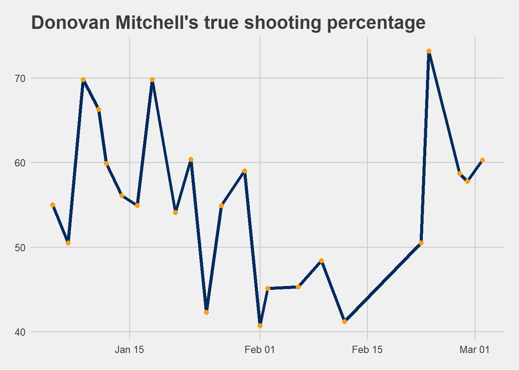

```r
# filter for Donovan again and arrange by date
DM45 <- playersSub %>% filter(player_name == "Donovan Mitchell") %>%
  arrange(desc(game_date))
# plot data
ggplot(DM45, aes(game_date,TSP)) + geom_path(size = 1.5, color = "#002B5C") +
  geom_point(size = 2, color = "#F9A01B") +
  ggtitle("Donovan Mitchell's true shooting percentage") + theme_fivethirtyeight()
```

It looks like he started out great, had a rough stretch, and has been shooting well the last few games.

## Mitchell’s best games vs other stars

Let’s see how he does in his best (most efficient) games compared to other stars during this stretch. We’ll look at players averaging more than 20 points per game during this period. I’ll use a true shooting percentage above 60, as that represents the upper quartile of performance. What this should show is who can score the most points while still being efficient.

```r
# true shooting percentage quartiles
TSPsum <- summary(playersummary$TSP)
# filter best scorers
stars <- playersummary %>% filter(PPG >= 20)
# filter by best scorers and TSP above 60
starsStats <- playersSub %>% filter(player_name %in% stars$Player, TSP > 60) %>%  arrange(desc(TSP))
# recalculate games played
starsStats <- starsStats %>% group_by(player_name) %>% mutate(games = n())
# summarize data for each player
starSummary <- starsStats %>% group_by(player_name) %>%
  summarize_at(vars(pts,fga,fta),sum)
# add games played to data
games <- starsStats %>% select(player_name,games) %>% summarize_at(vars(games),max)
starSummary <- left_join(starSummary,games, by = 'player_name')
# calculate overall true shooting percentage and points per game and sort by scoring
starSummary <- starSummary %>% group_by(player_name) %>%
  mutate(TSP = TSPcalc(pts,fga,fta), PPG = round(pts/games,1)) %>% arrange(desc(PPG))
# get pretty column names
names(starSummary) <- toupper(names(starSummary))
names(starSummary)[1] <- "Player"
# display table of top ten scorers
formattable(starSummary[1:10,], align = c('l','c','c'),
            list(PPG = color_tile("yellow","green"),
                 TSP = color_tile("yellow","green")))
```

| Player | PTS | FGA | FTA | GAMES | TSP | PPG |
| --- | --- | --- | --- | --- | --- | --- |
| James Harden | 713 | 446 | 214 | 16 | 66.0 | 44.6 |
| Paul George | 405 | 241 | 104 | 11 | 70.6 | 36.8 |
| Russell Westbrook | 173 | 115 | 42 | 5 | 64.8 | 34.6 |
| Donovan Mitchell | 196 | 131 | 43 | 6 | 65.4 | 32.7 |
| Stephen Curry | 452 | 283 | 53 | 14 | 73.8 | 32.3 |
| Giannis Antetokounmpo | 540 | 318 | 180 | 17 | 68.0 | 31.8 |
| Kemba Walker | 285 | 204 | 49 | 9 | 63.2 | 31.7 |
| Bradley Beal | 463 | 297 | 95 | 15 | 68.3 | 30.9 |
| Joel Embiid | 277 | 147 | 110 | 9 | 70.9 | 30.8 |
| Blake Griffin | 430 | 264 | 123 | 14 | 67.6 | 30.7 |

I’m actually a little surprised to see Mitchell in the top 10. He’s only had six games that match the criteria, but in those games he has been money. I’m not surprised to see him next to Westbrook, as both can be streaky players. Here’s hoping that streakiness is a temporary, early-career problem, not a permanent weakness.

## Wins and losses

Last, let’s look at how he does in wins and losses over the course of the entire season.

```r
# filter Donovan Mitchell from the full season log
DM45 <- players %>% filter(player_name == "Donovan Mitchell")
# get true shooting percentage
DM45 <- DM45 %>% mutate(TSP = TSPcalc(pts,fga,fta))
results <- DM45 %>% group_by(win) %>% mutate(TSP = mean(TSP),PTS = mean(pts),
                                             FGM = mean(fgm),
                                             FGA = mean(fga)) %>%
  select(c(9,28:31))  %>%
  distinct()
results[,2:5] <- round(results[,2:5],1)
names(results) <- toupper(names(results))
formattable(results, align = "c")
```

| WIN | TSP | PTS | FGM | FGA |
| --- | --- | --- | --- | --- |
| TRUE | 55.5 | 24.2 | 8.7 | 19.2 |
| FALSE | 46.8 | 22.1 | 8.0 | 21.3 |

One last look to see if this changes over the time span we’ve been looking at.

```r
# filter Donovan Mitchell from the full season log
DM45 <- playersSub %>% filter(player_name == "Donovan Mitchell")
# get true shooting percentage
DM45 <- DM45 %>% mutate(TSP = TSPcalc(pts,fga,fta))
results <- DM45 %>% group_by(win) %>% mutate(TSP = mean(TSP),PTS = mean(pts),
                                             FGM = mean(fgm),
                                             FGA = mean(fga)) %>%
  select(c(9,28,30:32))  %>%
  distinct()
results[,2:5] <- round(results[,2:5],1)
names(results) <- toupper(names(results))
formattable(results, align = "c")
```

| WIN | TSP | PTS | FGM | FGA |
| --- | --- | --- | --- | --- |
| TRUE | 57.3 | 28.2 | 10.0 | 21.6 |
| FALSE | 50.1 | 28.8 | 9.8 | 26.0 |

This last look is a bit more informative I think. Mitchell actually scores slightly more in a loss. Mainly he’s just taking four and a half fewer shots in wins while making basically the same number of shots. In other words, he’s a lot more efficient in a win.

I’m a big Donovan Mitchell fan, and I love the way he and the team are playing. I also can’t place his efficiency solely on his shoulders. Mitchell’s efficiency will improve, but I think he’s going to need someone else who can create their own shot to take some pressure off him.

**You’ll need a little knowledge of R to follow along, but it’s free, open source, and used by some of the top scientists, journalists, and data scientists around the world. Best of all, there are a lot of tutorials and guides online.*